# Classification with Deep Learning

MBAN - Winter 2024

Author

Dr. Aydede

Applying deep learning to classification problems introduces some differences in model architecture, training process, and evaluation compared to regression problems. Here’s an overview of these differences and some key considerations:

**Model Outcome and Activation Function**

Regression models typically have a single output unit without an activation function (or with a linear activation function), predicting a continuous quantity. For binary classification, there’s usually a single output unit with a sigmoid activation function. The sigmoid function maps the output to a probability score between 0 and 1, indicating the likelihood of the input belonging to the positive class.

For multi-class classification, the output layer has one unit per class and uses the softmax activation function. The softmax function converts the model outputs to probabilities that sum to 1, with each value representing the probability that the input belongs to one of the classes.

**Loss Function**  
Regression models commonly use mean squared error (MSE) or mean absolute error (MAE) as the loss function. For binary classification, the binary cross-entropy loss function is standard. For multi-class classification, categorical cross-entropy (or softmax cross-entropy) loss is typically used. This loss function compares the predicted class probabilities with the true class labels and penalizes the model based on the difference between them.

More detailed explanation of the loss functions is provided in Chapter 5.2.2. in the book.

Cross-entropy loss is a measure of the difference between two probability distributions: the predicted distribution (output of the model) and the true distribution (one-hot encoded labels). The goal is to minimize this difference during training. The cross-entropy loss is defined as:

$$\text{Cross-Entropy Loss} = -\sum_{i} y_i \log(p_i)$$

where $y_i$ is the true class label (0 or 1 for binary classification, one-hot encoded for multi-class classification), and $p_i$ is the predicted probability for class $i$. For a binary classification, we have two possible outcomes: the true label $y$ is either 0 or 1 , and the predicted probability (from the neural network) is $p$. The binary cross-entropy loss for a single observation is:

$$L(y, p)=-[y \log (p)+(1-y) \log (1-p)]$$

- If the true label $y=1$, the loss becomes $L(1, p)=-\log (p)$. As $p$ (the predicted probability of the positive class) decreases, $-\log (p)$ increases, meaning the loss increases when the model’s prediction is further from the actual class.
- If the true label $y=0$, the loss becomes $L(0, p)=-\log (1-p)$. As $p$ increases, $-\log (1-$ $p$ ) increases, meaning the loss increases when the model’s prediction is incorrectly confident in the positive class.

This loss function effectively penalizes predictions that are confident and wrong, encouraging the model to produce probabilities close to the actual labels. And the total loss is

$$J=\sum_{i=1}^n y_i \log p\left(x_i\right)+\left(1-y_i\right) \log \left(1-p\left(x_i\right)\right),$$
where for each observation,

$$p\left(\mathbf{x}_{\mathbf{i}}\right)=\frac{e^{\beta_0+\beta x_i}}{1+e^{\beta_0+\beta x_i}}$$
If the activation function is the sigmoid function.

**Probabilistic Model and Thresholding** Neural networks can be considered probabilistic in the context of classification. The output layer (using sigmoid or softmax) provides probabilities indicating the likelihood of each class. Although the raw output of the network provides these probabilities, making a final class decision often requires thresholding

As before, we cannot use a common threshold, like 0.5, for the sigmoid output. We need to rely on AUC. In multi-class classification, the class with the highest probability (from the softmax output) is typically selected as the model’s prediction.

Unlike regression, where you might use MSE or MAE, classification models are often evaluated using accuracy, precision, recall, F1 score. We use, however, a complex metrics like ROC-AUC or confusion matrices, depending on the specific requirements of the problem.

# 1 Classification with `neuralnet` Package

## 1.1 Binary Classification.

The goal is to predict whether a client will subscribe to a term deposit (variable $y$) based on various features such as age, job, marital status, education, and economic indicators.

```r
library(caret)
library(dplyr)
library(readr)
library(skimr)
library(ROCR)

df <- read_delim("bank.csv", delim = ";",
                   escape_double = FALSE, trim_ws = TRUE)

# Scaling and Dummy coding
df[,sapply(df, is.numeric)] <- scale((df[, sapply(df, is.numeric)]))
ddf <- model.matrix(~.-1, data = df, contrasts.arg =
                       lapply(df[ ,sapply(df, is.factor)],
                              contrasts, contrasts = FALSE))

# Colnames have to be cleaned
ddf <- as.data.frame(ddf)
clean_names <- make.names(names(ddf), unique = TRUE)
names(ddf) <- clean_names

# formula to pass on ANN and lm()
y.ind <- which(colnames(ddf) == "yyes")
frm <- as.formula(paste("yyes~", paste(colnames(ddf[-y.ind]), collapse = '+')))
```

We are ready

```r
library(neuralnet)

set.seed(1)
trainid <- sample(nrow(ddf), nrow(ddf), replace = TRUE)
train <- ddf[trainid, ]
test <- ddf[-trainid, ]

fit.ln <- glm(frm, data = train, family = binomial(link = "logit"))
fit.nn <- neuralnet(frm,
                    data = train,
                    hidden = c(4),
                    threshold = 0.05,
                    linear.output = FALSE,
                    err.fct = "ce")
#Predictions
phat.ln <- predict(fit.ln, test, type = "response")
phat.nn <- predict(fit.nn, test, type = "response")

#AUC for Logisitic Regression
pred_rocr1 <- ROCR::prediction(phat.ln, test$yyes)
auc_ROCR1 <- ROCR::performance(pred_rocr1, measure = "auc")
auc_ROCR1@y.values[[1]]
```

```
[1] 0.8898925
```

```r
#AUC for Neural Network
pred_rocr2 <- ROCR::prediction(phat.nn, test$yyes)
auc_ROCR2 <- ROCR::performance(pred_rocr2, measure = "auc")
auc_ROCR2@y.values[[1]]
```

```
[1] 0.848363
```

## 1.2 Multi-Class Classification

```r
dfr <- read.csv("wineQualityReds.csv", header = TRUE)
dfr <- dfr[, -1] # removing the index
table(dfr$quality)
```

```
  3   4   5   6   7   8
 10  53 681 638 199  18
```

```r
# Let's remove the outlier qualities:
indo <- which(dfr$quality == "3" | dfr$quality == "8")
dfr <- dfr[-indo, ]
dfr$quality <- as.factor(dfr$quality)
table(dfr$quality)
```

```
  4   5   6   7
 53 681 638 199
```

Ready?

```r
# Scaling and Dummy coding
dfr[, sapply(dfr, is.numeric)] <-
  scale((dfr[, sapply(dfr, is.numeric)]))

ddf <- model.matrix( ~ quality - 1, data = dfr)
y.ind <- which(colnames(dfr) == "quality")
dfr <- dfr[, -y.ind] # removing 'quality`
df <- cbind(ddf, dfr)

frm <- as.formula(paste(
  paste(colnames(ddf), collapse = '+'),
  "~",
  paste(colnames(dfr), collapse = '+')
))

frm
```

```
quality4 + quality5 + quality6 + quality7 ~ fixed.acidity + volatile.acidity +
    citric.acid + residual.sugar + chlorides + free.sulfur.dioxide +
    total.sulfur.dioxide + density + pH + sulphates + alcohol
```

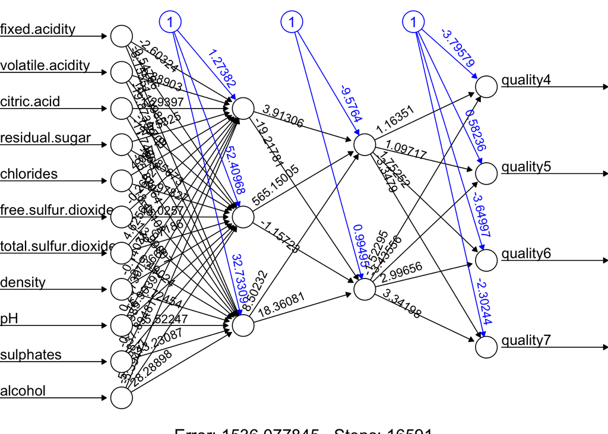

```r
library(neuralnet)
ind <- sample(nrow(df), nrow(df) * 0.7)
train <- df[ind, ]
test <- df[-ind, ]

fit.nn <-
  neuralnet(
    frm,
    data = train,
    hidden = c(3, 2),
    threshold = 0.05,
    linear.output = FALSE,
    err.fct = "ce"
  )

plot(fit.nn, rep = "best")
```

```r
phat <- predict(fit.nn, test)
head(phat)
```

```
         [,1]      [,2]       [,3]        [,4]
1  0.06708968 0.8428427 0.13039743 0.003503982
7  0.06708968 0.8428427 0.13039744 0.003503982
9  0.06694095 0.8421306 0.13092908 0.003522256
10 0.02201383 0.6420361 0.02540666 0.090455430
11 0.04582033 0.6831998 0.24920774 0.008458055
13 0.04581637 0.6831557 0.24924104 0.008459719
```

```r
# Assigning label by selecting the highest phat
label.hat <- t(apply(phat, 1, function(x) as.numeric(x == max(x))))
head(label.hat)
```

```
   [,1] [,2] [,3] [,4]
1     0    1    0    0
7     0    1    0    0
9     0    1    0    0
10    0    1    0    0
11    0    1    0    0
13    0    1    0    0
```

```r
# Confusion Table
pred <- apply(phat, 1, which.max)
fck <- colnames(test)[1:4]
predicted <- fck[pred]

act <- apply(test[ ,1:4], 1, which.max)
actual <- fck[act]

table(predicted, actual)
```

```
          actual
predicted  quality4 quality5 quality6 quality7
  quality5       14      136       76        7
  quality6        1       44       83       23
  quality7        1        9       32       46
```

Now AUC

```r
library(pROC)

test_labels <- test[ ,1:4]  # Extracting the first 4 columns as the true labels

# Calculate AUC for each class and store it
aucs <- sapply(1:ncol(test_labels), function(i) {
  roc_auc <- roc(test_labels[ ,i], phat[ ,i])$auc
  return(roc_auc)
})

# Calculate the average AUC across all classes
unlist(aucs)
```

```
[1] 0.7214912 0.7501823 0.6371225 0.8523724
```

```r
mean_auc <- mean(aucs)

print(mean_auc)
```

```
[1] 0.7402921
```

# 2 `keras` Package

First the preprocessing

```r
library(keras)
library(tensorflow)
library(caret) # for dummyVars
# Clearing the workspace
rm(list = ls())

dfr <- read.csv("wineQualityReds.csv", header = TRUE)
dfr <- dfr[, -1] # removing the index
indo <- which(dfr$quality == "3" | dfr$quality == "8")
dfr <- dfr[-indo, ]

# Adjust the target variable for multi-class classification
quality_categorical <- to_categorical(dfr$quality - min(dfr$quality))
df_transformed <- dfr[, -which(names(dfr) == "quality")]

indexes <- sample(1:nrow(dfr), size = 0.8 * nrow(dfr)) # Randomly sample 80% of the data
train_x <- df_transformed[indexes, ]
test_x <- df_transformed[-indexes, ]
train_y <- quality_categorical[indexes, ]
test_y <- quality_categorical[-indexes, ]

# There are 4 classes after your preprocessing
model <- keras_model_sequential() %>%
  layer_dense(units = 32, activation = 'relu', input_shape = c(ncol(train_x))) %>%
  layer_dense(units = 32, activation = 'relu') %>%
  layer_dense(units = 4, activation = 'softmax') # Update this to match the number of classes

# Compile the model for multi-class classification
model %>% compile(
  loss = 'categorical_crossentropy', # Correct loss function for multi-class
  optimizer = 'adam',
  metrics = list(metric_binary_accuracy(), tf$keras$metrics$AUC(name = "auc")) # Accuracy is a common metric for classification
)

# Fit the model
history <- model %>% fit(
  x = as.matrix(train_x),
  y = train_y,
  epochs = 100,
  batch_size = 128,
  validation_split = 0.2,
  verbose = 0
)

# Predictions as probabilities
predictions <- model %>% predict(as.matrix(test_x))
```

```
10/10 - 0s - 56ms/epoch - 6ms/step
```

```r
head(predictions)
```

```
            [,1]      [,2]      [,3]       [,4]
[1,] 0.039158147 0.5550810 0.3056373 0.10012361
[2,] 0.033092000 0.5995688 0.2665370 0.10080221
[3,] 0.056750208 0.3263209 0.4218948 0.19503412
[4,] 0.004666863 0.8274361 0.1165959 0.05130106
[5,] 0.044445198 0.4154477 0.3806851 0.15942203
[6,] 0.020941541 0.3547527 0.4376594 0.18664636
```

```r
# Evaluate the model on the test set
test_x_matrix <- as.matrix(test_x)

model %>% evaluate(test_x_matrix, test_y, verbose = 1)
```

```
           loss binary_accuracy             auc
      1.0066620       0.7650794       0.8163316
```

Now AUC

```r
library(pROC)

# Initialize an empty vector to store AUC for each class
aucs <- c()

# Calculate AUC for each class
for (i in 1:ncol(test_y)) {
  roc_res <- roc(response = test_y[, i], predictor = predictions[, i])
  aucs[i] <- auc(roc_res)
}

# Calculate mean AUC across all classes
mean_auc <- mean(aucs)

print(aucs)
```

```
[1] 0.5496743 0.7410581 0.5946349 0.8059166
```

```r
print(mean_auc)
```

```
[1] 0.672821
```

In Keras, when compiling the model, the metrics parameter is used to specify the metrics that will be evaluated by the model during training and testing. However, directly measuring AUC during training as a metric within the compile function wasn’t originally supported in earlier versions of Keras. This limitation was primarily due to AUC being a more complex calculation that requires the entire dataset’s predictions to compute accurately, as opposed to metrics like accuracy, which can be calculated batch-wise.

However, with updates to TensorFlow and Keras, you now have the ability to include AUC as a metric during model compilation if you are using a version of TensorFlow that supports it (TensorFlow 2.2.0 and later). You can do this by using `tf$keras$metrics$AUC()`.

# 3 PyTorch and Keras

PyTorch and Keras are both popular open-source libraries for deep learning, but they have different design philosophies, ecosystems, and usage patterns. Here’s a brief overview of both:

**PyTorch**

Developed by Facebook’s AI Research lab (FAIR).

- Dynamic Computation Graphs: PyTorch uses dynamic computation graphs (also known as define-by-run paradigm), which means the graph is built on the fly as operations are executed. This feature provides a more intuitive approach for dynamic models and iterative processes, making debugging easier and more interactive.
- Pythonic Nature: It seamlessly integrates with the Python data science stack (e.g., NumPy, SciPy) and supports native Python debugging tools. Its API and model definitions are very Pythonic, so it feels more like writing standard Python code.
- Strong GPU Acceleration: PyTorch provides strong support for CUDA and cuDNN, allowing efficient and easy GPU computation.
- Research and Flexibility: Initially favored more by researchers due to its flexibility and dynamic graph feature, which is ideal for experimental projects and rapid prototyping.

**Keras**

Developed by François Chollet - initially as an independent project, now part of TensorFlow under the TensorFlow umbrella managed by Google.

- High-Level API: Keras is designed as a high-level neural networks library. It runs on top of other deep learning libraries like TensorFlow, Theano, or Microsoft Cognitive Toolkit (CNTK). However, since TensorFlow 2.0, Keras has been integrated more deeply into TensorFlow as tf.keras.
- Ease of Use: It focuses on being user-friendly, modular, and extensible. It provides high-level building blocks for developing deep learning models with a few lines of code, making it accessible for beginners.
- Static Computation Graphs (with TensorFlow backend): TensorFlow (and thereby Keras, when used with TensorFlow as the backend) primarily uses static computation graphs, meaning the model’s structure is defined and compiled before it’s run. This approach can lead to faster execution and easier deployment of models but might be less intuitive for dynamic model adjustments.
- Wide Adoption in Industry: Due to its simplicity and TensorFlow’s strong support, Keras has seen wide adoption in the industry for developing and deploying production models. Differences at a Glance

PyTorch offers a more dynamic and intuitive approach (dynamic computation graphs) that’s particularly suited for research and projects where model architectures change frequently. Keras, especially as part of TensorFlow, focuses on ease of use and quick deployment, making it an excellent choice for beginners and applied deep learning projects.

Both have strong communities. PyTorch is often cited as the go-to for academic research and projects requiring dynamic models, while Keras (through TensorFlow) has a broad adoption in industry with extensive support for production deployment. Keras is generally considered easier to learn for beginners due to its high-level API, while PyTorch, with its Pythonic design and dynamic nature, is also very approachable, especially for those who have a solid grounding in Python.

Choosing between PyTorch and Keras (TensorFlow) often comes down to personal preference, project requirements, and specific features or functionalities that one might need for their deep learning tasks.

**Is R Competitive in Neural Networks?**

R is a programming language and environment primarily used for statistical computing and graphics. It’s heavily used in academia, research, and industry for statistical analysis, data visualization, and data science.

When it comes to neural networks and deep learning, R is not as prominently featured as Python. The Python ecosystem, with libraries like TensorFlow, Keras, and PyTorch, has become the de facto standard for deep learning research and development due to its extensive libraries, community support, and flexibility.

However, this does not mean R is not competitive or incapable of deep learning tasks. R has packages such as `keras` and `tensorflow` that provide interfaces to Keras and TensorFlow, respectively, allowing R users to build and train deep learning models within the R environment. There are also other packages and tools for machine learning and advanced statistical modeling.

The choice between R and Python often comes down to personal preference, specific project requirements, and the ecosystem one is more comfortable with. For users deeply embedded in the R ecosystem, especially those working in statistics, bioinformatics, or fields where R has strong domain-specific libraries, continuing in R for deep learning tasks might be preferable. For new projects or users starting from scratch, especially with a focus on deep learning, Python might offer a more direct path to a wide range of tools and community support.

We will continue on this topic in a Jupiter notebook.